# Beyond sight

Exploring the Impact of a Multifaceted Intervention on Knowledge, Attitudes and Behaviors towards Persons with Visual Impairment

Sergiu Burlacu

sburlacu@irvapp.it

FBK-IRVAPP

Davide Azzolini

FBK-IRVAPP

Federico Podestà

FBK-IRVAPP

July 26, 2024

## Motivation

### Social Inclusion at school

Persons with disabilities face much higher risks of poverty and social exclusion

- In ECON a lot of the focus is placed on labor market policies
  - e.g. employment quotas, wage subsidies etc. (Krekó and Telegdy 2022)
- Discrimination however is systemic and starts earlier in life with the educational system

Over the past 50 years most EU countries either abolished or reduced to a great extent special schools

- However, being placed in an integrated classrooms does not suffice (Lindsay and Edwards 2013)
  - Negative attitudes, limited acceptance and peer social interaction (Nabors and Keyes 1997; Martinez and Carspecken 2007; Tavares 2011)
  - Teachers often lack the training to foster inclusive classroom environments and may themselves have limited awareness and biased attitudes (Garrote et al. 2020; Ginevra et al. 2022)

Can external interventions support schools to create more inclusive environments?

## This paper in a nutshell

Evaluate the impact of a multifaceted intervention on a wide range of “social-inclusion” outcomes in the context of visual impairment

- Multifaceted intervenion
  - Information provision
  - Simulation | Perspective-taking exercise
  - Integroup-contact
- Outcomes
  - Skills - knowledge of visual impairment and perspective-taking & empathic concerns
  - Attitudes - explicit (self-reported) and implicit (IAT)
  - Incentivized beliefs and social preferences (willingness to interact socially and altruism)
- Results
  - Large positive effects on skills
  - Mixed effects on attitudes
  - No effects on any of the incentivized measures

## Contributions

- Disability Inclusion interventions in the school setting (Lindsay and Edwards 2013)
  - one of the few papers addressing visual impairment and looking beyond knowledge and explicit attitudes
- Generally, to field and lab-in-the-field experiments on discrimination (see Bertrand and Duflo 2017 for a review; Alesina et al. 2024)

Through the intervention:

- Information provision (Haaland, Roth, and Wohlfart 2023)
- Empathic concerns and perspective taking for prejudice reduction and cooperation (Batson et al. 1997; Galinsky and Moskowitz 2000; Galinsky and Ku 2004; Simonovits, Kezdi, and Kardos 2018; Kardos, Kezdi, and Simonovits 2018; Alan et al. 2021)
- Literature on intergroup contact (Allport 1954; Pettigrew and Tropp 2005; Paluck, Green, and Green 2019; Bursztyn et al. 2021)

# Program and Evaluation Design

## Intervention

- Implemented in 3 upper secondary schools in Trento, North Italy (344 students)
  - Academic, technical and vocational tracks
  - 6 classes per school, two eligibility criteria
  - Delivered by a local NGO

#### Information treatment

1h class activity on:

- types of visual impairment
- strategies and tools for autonomy
- professions and activities that can be done in autonomy
- appropriate conduct during a social interaction
- what it is to live with a disability, acknowledging the challenges and adaptations

#### Perspective taking and Inter-group contact treatment

[figure not shown]

## Evaluation design and Data

#### Experimental Design

- Hybrid between and within class design
  - `Between` - 6 classes (2 per school) serve as `"pure control classes"` (N = 119)
  - `Within` - 12 `"main classes"` with randomization at individual level (N = 225)
  - Why? Increase power while providing some evidence on within class spillovers
- Waitlist design
- Phased-in design - everyone is eventually treated

#### Data

- Baseline | Endline => 2-3 weeks before | after treatment
- Sample characteristics at baseline:
  - Avg. Age 18; 52% females
  - Roughly 80% report no contact with persons with visual disabilities
  - 86% report speaking Italian at home
  - Good balance by treatment
- 11% attrition at endline, balanced by treatment

## Empirical strategy

#### Regression Specification<sup>1</sup>

$$Y_{it+1} = \gamma Di + Y_{it} + X_{it} \beta + \varepsilon_{it+1}$$

- Main classes
  - $Di = 1$ if received “Initial offer” `(IO)` or “Ever offer” `(EO)`
  - ITT and LATE estimands
  - `DREO` estimator as robustness (De Chaisemartin and Behaghel 2020)
- Main vs pure controls
  - $Di = 1$ if never offered the treatment in “main classes” and 0 if in “pure control classes”
  - Fischer exact tests
[^1]: Nonparametric tests for some of the outcomes

# Outcomes and Results

## Results

### Skills

#### Outcomes

- `Knowledge`: quiz on visual impairment
- Perspective-taking (`PT`) and Empatic Concerns (`EC`)
  - subscales of the Interpersonal Reactivity Index (Davis 1980)

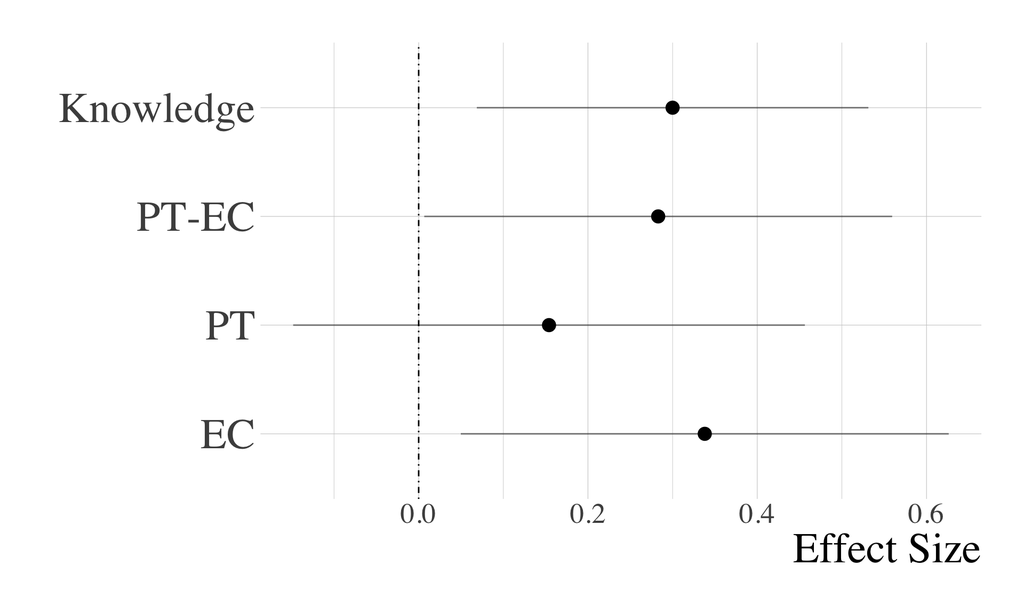

Positive effects on dimensions more closely related to the intervention

## Results

### Attitudes

#### Outcomes

- Implicit attitudes
  - Implicit Association Test adapted for visual impairment (`IAT`) (Greenwald, McGhee, and Schwartz 1998)
- General attitudes towards persons with visual disabilities (`ATDP`) (Yuker et al. 1970)
- Multidimensional Attitudes based on a social vignette (`MAS`) (Findler, Vilchinsky, and Werner 2007)
  - 3 dimensions: affect (emotions), cognition (thoughts) and behaviors

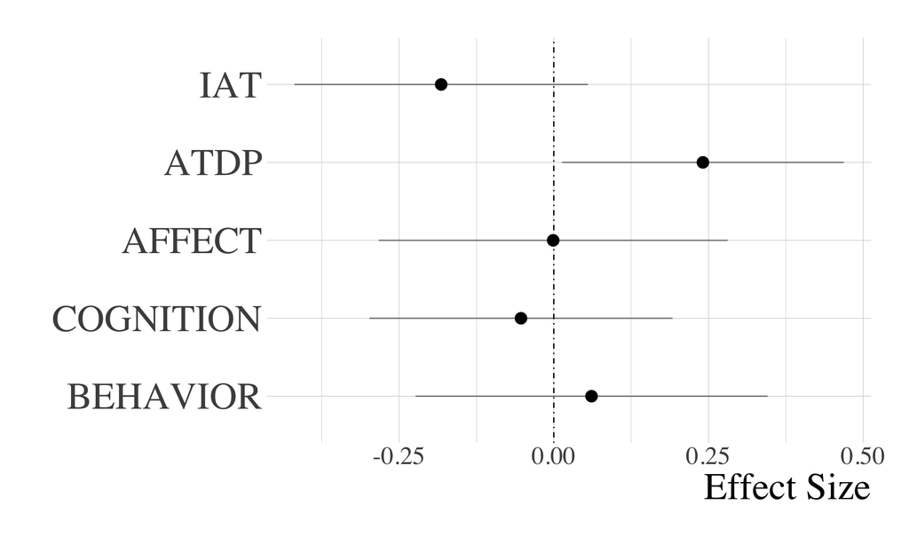

## Results

### Social Preferences

#### Outcomes

- Willingness to pay for social interaction (`WTP`)
- Giving in the Dictator Game to an anonymous blind recipient (`Giving Blind`)

#### Additional outcomes

- Giving towards a recipient with motor impairment (`Giving motor`) or a generic recipient (`Giving generic`)
- Social Value Orientation (`SVO`) (Murphy, Ackermann, and Handgraaf 2011; Murphy and Ackermann 2014)

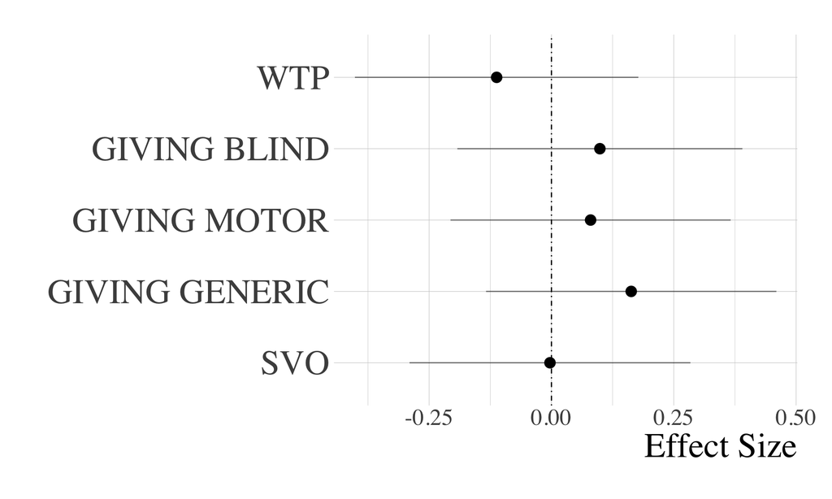

## Results

### Beliefs

**Instructions**

As you probably know, in 2021, the summer Olympic and Paralympic games were organized in Tokio, Japan.

One of the competitions was the female 400m meters sprint. You can watch below the recording of the competition in the Olympics.

In the Paralympics, the competition is organized separately for types of disability.

Guess the average time of participants with visual impairment in the Paralympcs game!

Other games:

- performance in a memory test
- performance in a math test (summation and multiplication)
- reported life-satisfaction in a representative survey

## Results

### Beliefs

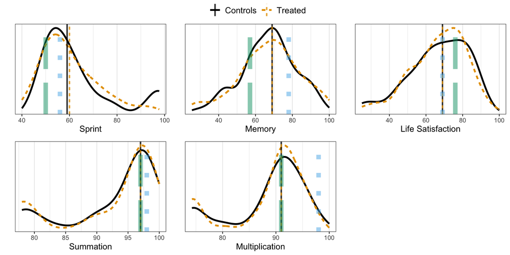

## Potential Concerns

### Social Desirability and Spillovers

#### Social Desirability

- Propensity to give socially desireble answers measured at endline (Crowne and Marlowe 1960; Manganelli, Canova, and Marcorin 2000)
  - Positive ES of 0.09 (p-value = 0.53)
  - Including it as endogenous control reduces ESs by 10-20%

#### Spillovers

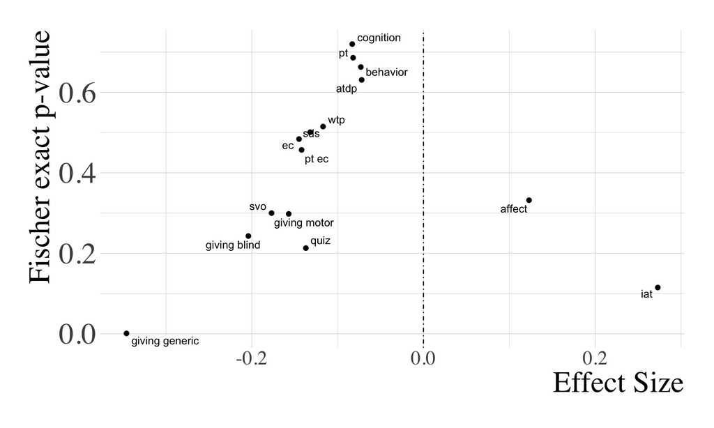

## Conclusion

- Main Findings
  - $(+)$ effects on knowledge and empathic concerns
  - $(+)$ effects on generalized attitudes
  - at best no impact on implicit attitudes
  - no impact on willingness to interact socially or expected emotions, thoughts and behaviors in the context of a social interaction
  - no impact on beliefs or altruism
- Main contribution: assessing impacts only on knowledge and self-reported attitudes may not paint the full picuture in terms of inclusion?
- Limitations
  - sample size and external validity
  - one shot intervention
  - no measure of actual behaviors

## References

Alan, Sule, Ceren Baysan, Mert Gumren, and Elif Kubilay. 2021. “Building Social Cohesion in Ethnically Mixed Schools: An Intervention on Perspective Taking.” *The Quarterly Journal of Economics* 136 (4): 2147–94.

Alesina, Alberto, Michela Carlana, Eliana La Ferrara, and Paolo Pinotti. 2024. “Revealing Stereotypes: Evidence from Immigrants in Schools.” *American Economic Review* 114 (7): 1916–48.

Allport, Gordon W. 1954. *The Nature of Prejudice*. Cambridge: Perseus Books.

Batson, C. Daniel, Marcia P. Polycarpou, Eddie Harmon-Jones, Heather J. Imhoff, Elizabeth C. Mitchener, Laura L. Bednar, and Thorsten R. Klein. 1997. “Empathy-Induced Altruism: A Research Perspective.” *The Empathy- Altruism Hypothesis* 35 (1): 51–62.

Bertrand, Marianne, and Esther Duflo. 2017. “Field Experiments on Discrimination.” In *Handbook of Economic Field Experiments*, 1:309–93.

Bursztyn, Leonardo, Thomas Chaney, Tarek Alexander Hassan, and Aakaash Rao. 2021. “The Immigrant Next Door: Long-Term Contact, Generosity, and Prejudice.” National Bureau of Economic Research.

Crowne, Douglas P, and David Marlowe. 1960. “A New Scale of Social Desirability Independent of Psychopathology.” *Journal of Consulting Psychology* 24 (4): 349.

Davis, Mark H. 1980. “Interpersonal Reactivity Index.”

De Chaisemartin, Clément, and Luc Behaghel. 2020. “Estimating the Effect of Treatments Allocated by Randomized Waiting Lists.” *Econometrica* 88 (4): 1453–77.

Findler, Lee, Noa Vilchinsky, and Shirli Werner. 2007. “The Multidimensional Attitudes Scale Toward Persons with Disabilities (MAS): Construction and Validation.” *Rehabilitation Counseling Bulletin* 50: 166–76.

Galinsky, Adam D., and Gillian Ku. 2004. “Perspective-Taking: Decreasing Stereotype Expression, Stereotype Accessibility, and in-Group Favoritism.” *Journal of Personality and Social Psychology* 86 (5): 713–27.

Galinsky, Adam D., and Gordon B. Moskowitz. 2000. “The Professional Identity of a ‘Street Cop’: A Defense Against Physical Threats.” *The Journal of Research in Personality* 34 (4): 427–47.

Garrote, Ariana, Franziska Felder, Helena Krähenmann, Susanne Schnepel, Rachel Sermier Dessemontet, Rachel Sermier Dessemontet, and Elisabeth Moser Opitz. 2020. “Social Acceptance in Inclusive Classrooms: The Role of Teacher Attitudes Toward Inclusion and Classroom Management.” *Frontiers in Education*. https://doi.org/10.3389/feduc.2020.582873.

Ginevra, Maria Cristina, Ilaria Di Maggio, Isabella Valbusa, Sara Santilli, and Laura Nota. 2022. “Teachers’ Attitudes Towards Students with Disabilities: The Role of the Type of Information Provided in the Students’ Profiles of Children with Disabilities.” *European Journal of Special Needs Education* 37 (3): 357–70.

Greenwald, Anthony G., Debbie E. McGhee, and Jordan L. K. Schwartz. 1998. “Measuring Individual Differences in Implicit Cognition: The Implicit Association Test.” *Journal of Personality and Social Psychology* 74 (6): 1646–1480.

Haaland, Ingar, Christopher Roth, and Johannes Wohlfart. 2023. “Designing Information Provision Experiments.” *Journal of Economic Literature* 61 (1): 3–40.

Kardos, Peter, Gabor Kezdi, and Andras Simonovits. 2018. “Religion and Support for Public Policies: Evidence from a Representative Survey in Hungary.” *European Sociological Review* 34 (3): 271–83.

Krekó, Judit, and Álmos Telegdy. 2022. “The Effects of a Disability Employment Quota When Compliance Is Cheaper Than Defiance.”

Lindsay, Sally, and Ann Edwards. 2013. “A Systematic Review of Disability Awareness Interventions for Children and Youth.” *Disability and Rehabilitation* 35: 623–46. https://doi.org/10.3109/09638288.2012.702850.

Manganelli, Anna-Maria, Luigina Canova, and R Marcorin. 2000. “La Desiderabilità Sociale. Un’analisi Di Forme Brevi Della Scala Di Marlowe e Crowne [Social Desirability. Analysis of the Short Forms of Marlowe’s and Crowne’s Scales].” *Testing, Psicometria, Metodologia* 7: 5–16.

Martinez, Rebecca S, and Phil Carspecken. 2007. “Effectiveness of a Brief Intervention on Latino Children’s Social Acceptance of Peers with Special Needs.” *Journal of Applied School Psychology* 23 (1): 97–115.

Murphy, Ryan O, and Kurt A Ackermann. 2014. “Social Value Orientation: Theoretical and Measurement Issues in the Study of Social Preferences.” *Personality and Social Psychology Review* 18 (1): 13–41.

Murphy, Ryan O, Kurt A Ackermann, and Michel JJ Handgraaf. 2011. “Measuring Social Value Orientation.” *Judgment and Decision Making* 6 (8): 771–81.

Nabors, Laura A, and Lynette A Keyes. 1997. “Brief Report: Preschoolers’ Social Preferences for Interacting with Peers with Physical Differences.” *Journal of Pediatric Psychology* 22 (1): 113–22.

Paluck, Elizabeth Levy, Seth A Green, and Donald P Green. 2019. “The Contact Hypothesis Re-Evaluated.” *Behavioural Public Policy* 3 (2): 129–58.

Pettigrew, Thomas F., and Linda R. Tropp. 2005. “Allport’s Intergroup Contact Hypothesis: Its History and Influence.” In *On the Nature of Prejudice: Fifty Years After Allport*, edited by John F. Dovidio, Oliver P. John, Peter Glick, and Laurie A. Rudman, 262–77. Malden: Blackwell Publishing.

Simonovits, Gábor, Gabor Kezdi, and Peter Kardos. 2018. “Seeing the World Through the Other’s Eye: An Online Intervention Reducing Ethnic Prejudice.” *American Political Science Review* 112 (1): 186–93.

Tavares, Wendy. 2011. “An Evaluation of the Kids Are Kids Disability Awareness Program: Increasing Social Inclusion Among Children with Physical Disabilities.” *Journal of Social Work in Disability and Rehabilitation*. https://doi.org/10.1080/1536710x.2011.546296.

Yuker, Harold E et al. 1970. “The Measurement of Attitudes Toward Disabled Persons.”

# Appendix

## Outcomes at baseline

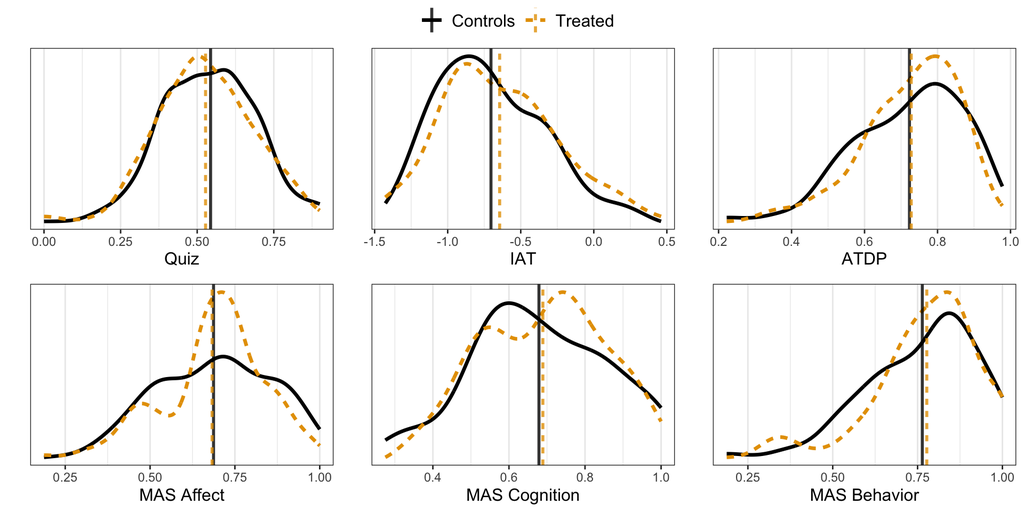

Back

## Outcomes at endline

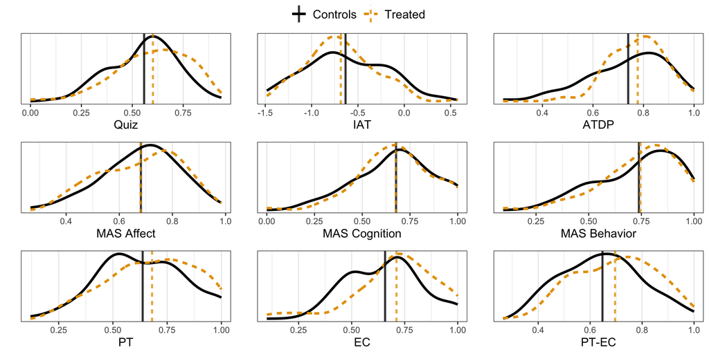

Back

## Outcomes at endline

[figure not shown]

Back

ERMAS 2024, UBB Cluj